# Analysez les ventes d'une librairie avec Python

### Etape 1.4 - Exploration du dataframe products

```python
# Afficher le nombre de lignes, de colonnes et de valeurs non-nulles dans chaque colonne
products.info()
```

```
<class 'pandas.core.frame.DataFrame'>
RangeIndex: 3286 entries, 0 to 3285
Data columns (total 3 columns):
 #   Column   Non-Null Count  Dtype
---  ------   --------------  -----
 0   id_prod  3286 non-null   object
 1   price    3286 non-null   float64
 2   categ    3286 non-null   int64
dtypes: float64(1), int64(1), object(1)
memory usage: 77.1+ KB
```

```python
# Afficher les 5 premières lignes du dataframe products
products.head()
```

|  | id_prod | price | categ |
| --- | --- | --- | --- |
| 0 | 0_1421 | 19.99 | 0 |
| 1 | 0_1368 | 5.13 | 0 |
| 2 | 0_731 | 17.99 | 0 |
| 3 | 1_587 | 4.99 | 1 |
| 4 | 0_1507 | 3.99 | 0 |

```python
# On vérifie s'il y a des doublons
products.duplicated().sum()
```

```
0
```

```python
# Vérifier l'unicité des clés primaires du dataframe, doit renvoyer 3286
products['id_prod'].unique().shape[0]
```

```
3286
```

```
Skewness: 3.79840808478482
```

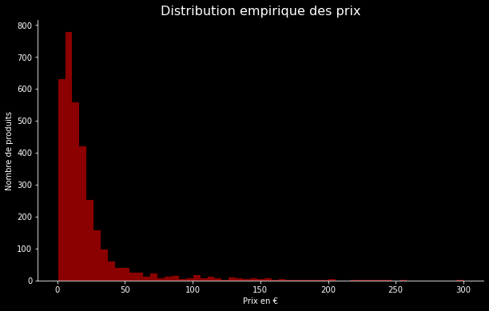

```python
# Visualiser la distribution de la variable prix et son skewness
# la distribution est étirée à droite avec une majorité de valeurs inférieures à la moyenne
# et une minorité de valeurs extrêmes largement supérieures à celle-ci
print('Skewness:', products['price'].skew())
plt.figure(figsize=(10, 6))
ax = products['price'].hist(bins=57, color='darkred')
plt.title('Distribution empirique des prix', fontsize=16)
plt.xlabel('Prix en €')
plt.ylabel('Nombre de produits')
ax.spines[['top', 'right']].set_visible(False)
plt.grid(False)
plt.show()
```

```python
# Afficher les indicateurs de tendance centrale et indicateurs de dispersion de la variable prix
def central_tendency_dispersion(df, df_variable):
    values = {}
    values['Nombre de valeurs non nulles'] = int(df[df_variable].count())
    values['Nombre de valeurs uniques'] = int(df[df_variable].nunique())
    values['min'] = round(df[df_variable].min(),2)
    values['max'] = round(df[df_variable].max(),2)
    values['étendue'] = round(values['max'] - values['min'],2)
    values['mode']  = round(df[df_variable].mode().values[0],2)
    values['médiane']  = round(df[df_variable].median(),2)
    values['moyenne']  = round(df[df_variable].mean(),2)
    values['variance'] = round(df[df_variable].var(),2)
    values['écart-type'] = round(df[df_variable].std(),2)
    results = pd.Series(values)
    return results

print(central_tendency_dispersion(products, 'price'))
```

```
Nombre de valeurs non nulles    3286.00
Nombre de valeurs uniques       1454.00
min                                0.62
max                              300.00
étendue                          299.38
mode                               4.99
médiane                           13.07
moyenne                           21.86
variance                         891.01
écart-type                        29.85
dtype: float64
```

```python
# Visualiser les outliers
def IQR_outliers(df, x):
    Q1 = df[x].quantile(0.25)
    Q3 = df[x].quantile(0.75)
    IQ = Q3 - Q1
    outliers = df[(df[x] < (Q1 - 1.5 * IQ)) | (df[x] > (Q3 + 1.5 * IQ))].sort_values(by=x, ascending=False)
    return outliers

price_outliers = IQR_outliers(products, 'price')
price_outliers
```

|  | id_prod | price | categ |
| --- | --- | --- | --- |
| 946 | 2_2 | 300.00 | 2 |
| 724 | 2_76 | 254.44 | 2 |
| 394 | 2_158 | 247.22 | 2 |
| 1435 | 2_167 | 236.99 | 2 |
| 2778 | 2_30 | 233.54 | 2 |
| ... | ... | ... | ... |
| 3168 | 1_626 | 47.35 | 1 |
| 2965 | 1_620 | 47.30 | 1 |
| 49 | 1_48 | 47.22 | 1 |
| 2265 | 1_569 | 46.99 | 1 |
| 1163 | 2_155 | 46.99 | 2 |

302 rows × 3 columns

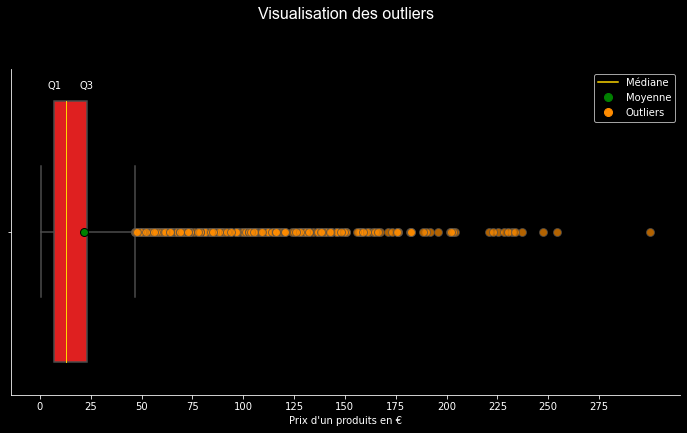

```python
# Visualiser les outliers à l'aide d'une boîte à moustaches
plt.figure(figsize=(12,6))

medianprops = dict(linestyle='-', linewidth=1, color='gold')
meanprops = dict(marker='o', markersize=8, markeredgecolor='black', markerfacecolor='green')
flierprops = dict(marker='o', markersize=8, markerfacecolor='darkorange', linestyle='none', alpha=0.7)

median_line = mlines.Line2D([], [], color='gold', label='Médiane')
mean_marker = mlines.Line2D([], [], color='green', marker='o', linestyle='None', markersize=8, label='Moyenne')
outliers_marker = mlines.Line2D([], [], color='darkorange', marker='o', linestyle='None', markersize=8, label='Outliers')

Q1 = products['price'].quantile(0.25)
Q3 = products['price'].quantile(0.75)

plt.annotate('Q1', xy=(Q1, 0), xytext=(Q1, -0.45), ha='center', va='center')
plt.annotate('Q3', xy=(Q3, 0), xytext=(Q3, -0.45), ha='center', va='center')

sns.boxplot(x='price', data=products, orient='h', color='red', medianprops=medianprops, meanprops=meanprops, showmeans=True, flierprops=flierprops)
plt.title("Visualisation des outliers",fontsize=16, fontfamily='Arial', loc='center', pad=50)
plt.xlabel('Prix d\'un produits en €')
xticks = np.arange(start=0, stop=products['price'].max(), step=25)
plt.xticks(xticks)
plt.legend(handles=[median_line, mean_marker, outliers_marker])
sns.despine()
plt.show()
```

```python
# Discrétisation de la variable prix avec l'ajout d'une colonne price_group
bins = [0, 50, 100, 150, 200, 250, 300]
labels = ['0-50', '50-100', '100-150', '150-200', '200-250', '250-300']
products['price_group'] = pd.cut(products['price'], bins=bins, labels=labels, include_lowest=True)
products.head()
```

|  | id_prod | price | categ | price_group |
| --- | --- | --- | --- | --- |
| 0 | 0_1421 | 19.99 | 0 | 0-50 |
| 1 | 0_1368 | 5.13 | 0 | 0-50 |
| 2 | 0_731 | 17.99 | 0 | 0-50 |
| 3 | 1_587 | 4.99 | 1 | 0-50 |
| 4 | 0_1507 | 3.99 | 0 | 0-50 |

```python
# Distribution empirique de la variable price_group
products['price_group'].value_counts()
```

```
0-50       3013
50-100      150
100-150      79
150-200      29
200-250      13
250-300       2
Name: price_group, dtype: int64
```

```python
# Afficher la distribution empirique de la variable catégorie :
products['categ'].value_counts()
```

```
0    2308
1     739
2     239
Name: categ, dtype: int64
```

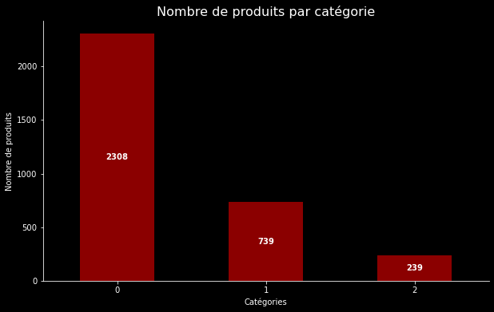

```python
# Visualiser la distribution empirique de la variable catégorie à l'aide d'un barplot
plt.figure(figsize=(10, 6))
ax = products['categ'].value_counts().plot(kind='bar', color='darkred')

plt.title('Nombre de produits par catégorie', fontsize=16)
plt.xlabel('Catégories')
plt.ylabel('Nombre de produits')

# Ajouter les effectifs sur les barres
for p in ax.patches:
    ax.annotate(str(p.get_height()), (p.get_x() + p.get_width() / 2., p.get_height() * 0.50), ha='center', va='center', color='white', fontweight='bold')

ax.spines[['top', 'right']].set_visible(False)
plt.xticks(rotation=0)
plt.grid(False)
plt.show()
```

```python
# Afficher la proportion de chaque catégorie dans le nombre total de produits
products['categ'].value_counts(normalize=True)
```

```
0    0.702374
1    0.224893
2    0.072733
Name: categ, dtype: float64
```

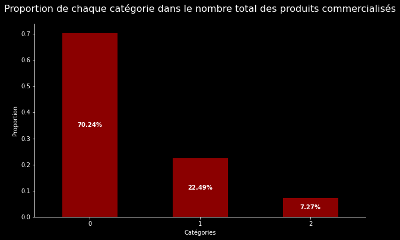

```python
# Visualiser la distribution empirique de la variable catégorie à l'aide d'un barplot
plt.figure(figsize=(10, 6))
ax = products['categ'].value_counts(normalize=True).plot(kind='bar', color='darkred')

plt.title('Proportion de chaque catégorie dans le nombre total des produits commercialisés', fontsize=16, pad=20)
plt.xlabel('Catégories')
plt.ylabel('Proportion')

# Ajouter les pourcentages sur les barres
for p in ax.patches:
    ax.annotate("{:.2%}".format(p.get_height()), (p.get_x() + p.get_width() / 2., p.get_height() * 0.50), ha='center', va='center', color='white', fontweight='bold')

ax.spines[['top', 'right']].set_visible(False)
plt.xticks(rotation=0)
plt.grid(False)
plt.show()
```

```python
# Changer le type de la variable categ en chaîne de caractères (vu qu'il s'agit d'une variable qualitative)
products['categ'] = products['categ'].astype(str)
```

### Etape 1.4 - Exploration du dataframe transactions

```python
# Afficher le nombre de lignes, de colonnes et de valeurs non-nulles dans chaque colonne
transactions.info()
```

```
<class 'pandas.core.frame.DataFrame'>
RangeIndex: 687534 entries, 0 to 687533
Data columns (total 4 columns):
 #   Column      Non-Null Count   Dtype
---  ------      --------------   -----
 0   id_prod     687534 non-null  object
 1   date        687534 non-null  object
 2   session_id  687534 non-null  object
 3   client_id   687534 non-null  object
dtypes: object(4)
memory usage: 21.0+ MB
```

```python
# Afficher les 5 premières lignes du dataframe transactions
transactions.head()
```

|  | id_prod | date | session_id | client_id |
| --- | --- | --- | --- | --- |
| 0 | 0_1259 | 2021-03-01 00:01:07.843138 | s_1 | c_329 |
| 1 | 0_1390 | 2021-03-01 00:02:26.047414 | s_2 | c_664 |
| 2 | 0_1352 | 2021-03-01 00:02:38.311413 | s_3 | c_580 |
| 3 | 0_1458 | 2021-03-01 00:04:54.559692 | s_4 | c_7912 |
| 4 | 0_1358 | 2021-03-01 00:05:18.801198 | s_5 | c_2033 |

```python
# renommer les identifiants de sessions et les convertir en entiers
transactions['session_id'] = transactions['session_id'].str.slice(2)  # retire les deux premiers caractères
transactions['session_id'] = transactions['session_id'].astype(int)
transactions.head()
```

|  | id_prod | date | session_id | client_id |
| --- | --- | --- | --- | --- |
| 0 | 0_1259 | 2021-03-01 00:01:07.843138 | 1 | c_329 |
| 1 | 0_1390 | 2021-03-01 00:02:26.047414 | 2 | c_664 |
| 2 | 0_1352 | 2021-03-01 00:02:38.311413 | 3 | c_580 |
| 3 | 0_1458 | 2021-03-01 00:04:54.559692 | 4 | c_7912 |
| 4 | 0_1358 | 2021-03-01 00:05:18.801198 | 5 | c_2033 |

```python
# renommer les identifiants des clients et les convertir en entiers
transactions['client_id'] = transactions['client_id'].str.slice(2)  # retirer les deux premiers caractères
transactions['client_id'] = transactions['client_id'].astype(int)
transactions.head()
```

|  | id_prod | date | session_id | client_id |
| --- | --- | --- | --- | --- |
| 0 | 0_1259 | 2021-03-01 00:01:07.843138 | 1 | 329 |
| 1 | 0_1390 | 2021-03-01 00:02:26.047414 | 2 | 664 |
| 2 | 0_1352 | 2021-03-01 00:02:38.311413 | 3 | 580 |
| 3 | 0_1458 | 2021-03-01 00:04:54.559692 | 4 | 7912 |
| 4 | 0_1358 | 2021-03-01 00:05:18.801198 | 5 | 2033 |

```python
# On vérifie s'il y a des doublons
transactions.duplicated().sum()
```

```
0
```

```python
# Afficher le nombre de produits uniques ayant fait l'objet d'une transaction, ne peut pas être supérieur à 3286
transactions['id_prod'].unique().shape[0]
```

```
3265
```

```python
# Afficher le nombre de clients uniques ayant effectué un achat
transactions['client_id'].unique().shape[0]
```

```
8600
```

```python
# Afficher le nombre de sessions uniques
number_of_unique_sessions = transactions['session_id'].unique().shape[0]
number_of_unique_sessions
```

```
345505
```

```python
# créer un dataframe avec une colonne affichant le nombre de produits achetés par session
# En effet, une transaction = un achat = un seul produit => donc une session (qui englobe souvent plusieurs produits) = un panier
transactions_per_session = transactions.groupby('session_id')['date'].nunique()
transactions_per_session = transactions_per_session.reset_index()
transactions_per_session.columns = ['session_id', 'nb_of_products_bought_during_session']
transactions_per_session.head()
```

|  | session_id | nb_of_products_bought_during_session |
| --- | --- | --- |
| 0 | 1 | 1 |
| 1 | 2 | 1 |
| 2 | 3 | 3 |
| 3 | 4 | 2 |
| 4 | 5 | 1 |

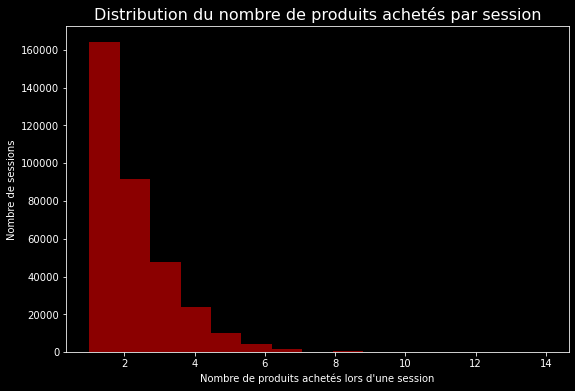

```python
# Afficher l'histogramme du nombre de produits achetés par session
plt.figure(figsize=(9,6))
transactions_per_session['nb_of_products_bought_during_session'].hist(bins=15, color='darkred')
plt.title('Distribution du nombre de produits achetés par session', fontsize=16)
plt.xlabel('Nombre de produits achetés lors d\'une session')
plt.grid(False)
plt.ylabel('Nombre de sessions')
```

```python
# Afficher le nombre maximum d'achats en une session
transactions_per_session['nb_of_products_bought_during_session'].max()
```

```
14
```

```python
# Ajouter une colonne au dataframe transactions
transactions = pd.merge(transactions, transactions_per_session, on='session_id')
transactions.head(15)
```

|  | id_prod | date | session_id | client_id | nb_of_products_bought_during_session |
| --- | --- | --- | --- | --- | --- |
| 0 | 0_1259 | 2021-03-01 00:01:07.843138 | 1 | 329 | 1 |
| 1 | 0_1390 | 2021-03-01 00:02:26.047414 | 2 | 664 | 1 |
| 2 | 0_1352 | 2021-03-01 00:02:38.311413 | 3 | 580 | 3 |
| 3 | 0_1638 | 2021-03-01 00:10:37.223732 | 3 | 580 | 3 |
| 4 | 0_1110 | 2021-03-01 00:38:57.630675 | 3 | 580 | 3 |
| 5 | 0_1458 | 2021-03-01 00:04:54.559692 | 4 | 7912 | 2 |
| 6 | 1_310 | 2021-03-01 00:17:11.089942 | 4 | 7912 | 2 |
| 7 | 0_1358 | 2021-03-01 00:05:18.801198 | 5 | 2033 | 1 |
| 8 | 0_1073 | 2021-03-01 00:05:44.999018 | 6 | 4908 | 3 |
| 9 | 0_279 | 2021-03-01 00:07:48.507530 | 6 | 4908 | 3 |
| 10 | 0_1475 | 2021-03-01 00:16:16.649539 | 6 | 4908 | 3 |
| 11 | 0_1304 | 2021-03-01 00:07:04.371179 | 7 | 1609 | 2 |
| 12 | 0_1159 | 2021-03-01 00:11:57.832228 | 7 | 1609 | 2 |
| 13 | 1_445 | 2021-03-01 00:09:11.523122 | 8 | 7991 | 1 |
| 14 | 1_556 | 2021-03-01 00:10:20.265265 | 9 | 6171 | 1 |

### Etape 1.5 - Lister les produits et les clients jamais impliqués dans une transaction

```python
# Récupérer les id des produits n'ayant fait l'objet d'aucune transaction
products_sold_at_least_once = transactions['id_prod'].unique()
products_not_sold = products.loc[~products['id_prod'].isin(products_sold_at_least_once)]
products_not_sold
```

|  | id_prod | price | categ | price_group |
| --- | --- | --- | --- | --- |
| 184 | 0_1016 | 35.06 | 0 | 0-50 |
| 279 | 0_1780 | 1.67 | 0 | 0-50 |
| 736 | 0_1062 | 20.08 | 0 | 0-50 |
| 793 | 0_1119 | 2.99 | 0 | 0-50 |
| 810 | 0_1014 | 1.15 | 0 | 0-50 |
| 845 | 1_0 | 31.82 | 1 | 0-50 |
| 1030 | 0_1318 | 20.92 | 0 | 0-50 |
| 1138 | 0_1800 | 22.05 | 0 | 0-50 |
| 1346 | 0_1645 | 2.99 | 0 | 0-50 |
| 1504 | 0_322 | 2.99 | 0 | 0-50 |
| 1529 | 0_1620 | 0.80 | 0 | 0-50 |
| 1542 | 0_1025 | 24.99 | 0 | 0-50 |
| 1708 | 2_87 | 220.99 | 2 | 200-250 |
| 1862 | 1_394 | 39.73 | 1 | 0-50 |
| 1945 | 2_72 | 141.32 | 2 | 100-150 |
| 2214 | 0_310 | 1.94 | 0 | 0-50 |
| 2407 | 0_1624 | 24.50 | 0 | 0-50 |
| 2524 | 2_86 | 132.36 | 2 | 100-150 |
| 2689 | 0_299 | 22.99 | 0 | 0-50 |
| 3030 | 0_510 | 23.66 | 0 | 0-50 |
| 3095 | 0_2308 | 20.28 | 0 | 0-50 |

```python
# Récupérer les id des clients n'ayant jamais effectué un achat
customers_who_purchased = transactions['client_id'].unique()
customers_who_never_purchased = customers.loc[~customers['client_id'].isin(customers_who_purchased)]
customers_who_never_purchased
```

|  | client_id | sex | birth | age | age_group |
| --- | --- | --- | --- | --- | --- |
| 801 | 8253 | female | 2001 | 23 | 20-29 |
| 2483 | 3789 | female | 1997 | 27 | 20-29 |
| 2734 | 4406 | female | 1998 | 26 | 20-29 |
| 2768 | 2706 | female | 1967 | 57 | 50-59 |
| 2850 | 3443 | male | 1959 | 65 | 60 and over |
| 3178 | 4447 | male | 1956 | 68 | 60 and over |
| 3189 | 3017 | female | 1992 | 32 | 30-39 |
| 3333 | 4086 | female | 1992 | 32 | 30-39 |
| 3720 | 6930 | male | 2004 | 20 | 20-29 |
| 3820 | 4358 | male | 1999 | 25 | 20-29 |
| 4723 | 8381 | female | 1965 | 59 | 50-59 |
| 4790 | 1223 | male | 1963 | 61 | 60 and over |
| 6111 | 6862 | female | 2002 | 22 | 20-29 |
| 6207 | 5245 | female | 2004 | 20 | 20-29 |
| 6337 | 5223 | male | 2003 | 21 | 20-29 |
| 6470 | 6735 | male | 2004 | 20 | 20-29 |
| 6584 | 862 | female | 1956 | 68 | 60 and over |
| 6827 | 7584 | female | 1960 | 64 | 60 and over |
| 7789 | 90 | male | 2001 | 23 | 20-29 |
| 7818 | 587 | male | 1993 | 31 | 30-39 |
| 8534 | 3526 | male | 1956 | 68 | 60 and over |

### Etape 1.5 - Fusion des dataframes et exploration du dataframe fusionné

```python
# On fusionne les 3 dataframes
# jointure interne entre products et transactions pour écarter les 21 produits qui ne figurent pas dans transactions
# puis nouvelle jointure interne pour ne récupérer que les clients ayant effectué au minimum une transaction.
df = pd.merge(products, transactions, on='id_prod', how='inner').merge(customers, on='client_id', how='inner')
df.sort_values(by='date').head()
```

|  | id_prod | price | categ | price_group | date | session_id | client_id | nb_of_products_bought_during_session | sex | birth | age | age_group |
| --- | --- | --- | --- | --- | --- | --- | --- | --- | --- | --- | --- | --- |
| 642805 | 0_1259 | 11.99 | 0 | 0-50 | 2021-03-01 00:01:07.843138 | 1 | 329 | 1 | female | 1967 | 57 | 50-59 |
| 293202 | 0_1390 | 19.37 | 0 | 0-50 | 2021-03-01 00:02:26.047414 | 2 | 664 | 1 | male | 1960 | 64 | 60 and over |
| 29695 | 0_1352 | 4.50 | 0 | 0-50 | 2021-03-01 00:02:38.311413 | 3 | 580 | 3 | male | 1988 | 36 | 30-39 |
| 226546 | 0_1458 | 6.55 | 0 | 0-50 | 2021-03-01 00:04:54.559692 | 4 | 7912 | 2 | female | 1989 | 35 | 30-39 |
| 301488 | 0_1358 | 16.49 | 0 | 0-50 | 2021-03-01 00:05:18.801198 | 5 | 2033 | 1 | female | 1956 | 68 | 60 and over |

```python
# Afficher (nombre de lignes, nombre de colonnes) du dataframe fusionné
df.shape
```

```
(687534, 12)
```

```python
# Renommer les colonnes date et birth pour plus de clarté
df = df.rename(columns={'date': 'transaction_date', 'birth' : 'year_of_birth'})
df.head()
```

|  | id_prod | price | categ | price_group | transaction_date | session_id | client_id | nb_of_products_bought_during_session | sex | year_of_birth | age | age_group |
| --- | --- | --- | --- | --- | --- | --- | --- | --- | --- | --- | --- | --- |
| 0 | 0_1421 | 19.99 | 0 | 0-50 | 2021-03-01 04:13:00.107748 | 101 | 8533 | 3 | male | 1972 | 52 | 50-59 |
| 1 | 0_1421 | 19.99 | 0 | 0-50 | 2022-10-01 04:13:00.107748 | 276043 | 8533 | 3 | male | 1972 | 52 | 50-59 |
| 2 | 0_1421 | 19.99 | 0 | 0-50 | 2022-12-01 04:13:00.107748 | 305391 | 8533 | 3 | male | 1972 | 52 | 50-59 |
| 3 | 0_1421 | 19.99 | 0 | 0-50 | 2023-01-01 04:13:00.107748 | 320253 | 8533 | 3 | male | 1972 | 52 | 50-59 |
| 4 | 0_2199 | 12.99 | 0 | 0-50 | 2021-03-25 17:43:48.819074 | 11366 | 8533 | 5 | male | 1972 | 52 | 50-59 |

La conversion de la colonne transaction_date au format datetime renvoie une erreur. Certaines valeurs seraient incompatibles avec le format datetime.  
Voyons cela de plus près.

```python
# Fonction qui va permettre de filtrer le dataframe
def check_date(date_str):
    # on s'assure que la valeur est bien une chaîne de caractères (car il y a quelques NaN correpondant aux clients n'ayant acheté aucun produit)
    if isinstance(date_str, str):
        # on récupére l'heure (11e et 12e caractères de la chaîne en partant de 0)
        hour = date_str[11:13]
        if hour == '24':
            return True
    return False

# On crée une colonne qui affiche True s'il existe une anomalie de format de date
df['anomalies'] = df['transaction_date'].apply(check_date)
```

```python
# On Visualise les anomalies
# pd.set_option('display.max_rows', 236)
df[df['anomalies'] == True].head(10)
```

|  | id_prod | price | categ | price_group | transaction_date | session_id | client_id | nb_of_products_bought_during_session | sex | year_of_birth | age | age_group | anomalies |
| --- | --- | --- | --- | --- | --- | --- | --- | --- | --- | --- | --- | --- | --- |
| 81244 | 1_348 | 16.15 | 1 | 0-50 | 2021-10-20 24:01:38.673154 | 101450 | 2713 | 1 | female | 1970 | 54 | 50-59 | True |
| 85926 | 1_257 | 22.99 | 1 | 0-50 | 2021-10-03 24:20:42.539778 | 100545 | 1365 | 3 | male | 1983 | 41 | 40-49 | True |
| 85952 | 1_403 | 17.99 | 1 | 0-50 | 2021-10-03 24:20:24.463408 | 100545 | 1365 | 3 | male | 1983 | 41 | 40-49 | True |
| 86081 | 1_475 | 20.99 | 1 | 0-50 | 2021-10-03 24:20:05.463408 | 100545 | 1365 | 3 | male | 1983 | 41 | 40-49 | True |
| 95801 | 1_683 | 13.99 | 1 | 0-50 | 2021-10-05 24:35:07.554906 | 103368 | 195 | 1 | male | 1957 | 67 | 60 and over | True |
| 98376 | 1_683 | 13.99 | 1 | 0-50 | 2021-10-11 24:51:58.640773 | 105904 | 7925 | 2 | female | 1984 | 40 | 40-49 | True |
| 98418 | 1_730 | 22.65 | 1 | 0-50 | 2021-10-11 24:51:10.640773 | 105904 | 7925 | 2 | female | 1984 | 40 | 40-49 | True |
| 107095 | 1_249 | 22.99 | 1 | 0-50 | 2021-10-20 24:54:31.664543 | 103234 | 7399 | 1 | female | 1988 | 36 | 30-39 | True |
| 112799 | 1_396 | 18.60 | 1 | 0-50 | 2021-10-10 24:45:24.678543 | 104373 | 5632 | 3 | male | 1956 | 68 | 60 and over | True |
| 112805 | 1_282 | 23.20 | 1 | 0-50 | 2021-10-10 24:45:57.116331 | 104373 | 5632 | 3 | male | 1956 | 68 | 60 and over | True |

```python
# Fonction pour transformer les 24 en 00 :
def correct_date(date_str):
    # on s'assure que la valeur est bien une chaîne de caractères (car il y a quelques NaN correpondant aux clients n'ayant acheté aucun produit)
    if isinstance(date_str, str):
        # on récupére l'heure (11e et 12e caractères de la chaîne en partant de 0)
        hour = date_str[11:13]
        if hour == '24':
            # on remplace 24 par 00 à l'aide d'une concaténation
            date_str = date_str[:11] + '00' + date_str[13:]
    return date_str
df['transaction_date'] = df['transaction_date'].apply(correct_date)
```

```python
# On vérifie si les changements ont été effectués
df[df['anomalies'] == True].head()
```

|  | id_prod | price | categ | price_group | transaction_date | session_id | client_id | nb_of_products_bought_during_session | sex | year_of_birth | age | age_group | anomalies |
| --- | --- | --- | --- | --- | --- | --- | --- | --- | --- | --- | --- | --- | --- |
| 81244 | 1_348 | 16.15 | 1 | 0-50 | 2021-10-20 00:01:38.673154 | 101450 | 2713 | 1 | female | 1970 | 54 | 50-59 | True |
| 85926 | 1_257 | 22.99 | 1 | 0-50 | 2021-10-03 00:20:42.539778 | 100545 | 1365 | 3 | male | 1983 | 41 | 40-49 | True |
| 85952 | 1_403 | 17.99 | 1 | 0-50 | 2021-10-03 00:20:24.463408 | 100545 | 1365 | 3 | male | 1983 | 41 | 40-49 | True |
| 86081 | 1_475 | 20.99 | 1 | 0-50 | 2021-10-03 00:20:05.463408 | 100545 | 1365 | 3 | male | 1983 | 41 | 40-49 | True |
| 95801 | 1_683 | 13.99 | 1 | 0-50 | 2021-10-05 00:35:07.554906 | 103368 | 195 | 1 | male | 1957 | 67 | 60 and over | True |

```python
# Suppression de la colonne anomalies
df.drop(columns='anomalies', inplace=True)
```

```python
# Convertir la colonne transaction_date au format datetime
df['transaction_date'] = pd.to_datetime(df['transaction_date'])

# Vérifier si la variable transaction_date est maintenant de type datetime
df.dtypes
```

```
id_prod                                         object
price                                          float64
categ                                           object
price_group                                   category
transaction_date                        datetime64[ns]
session_id                                       int32
client_id                                        int32
nb_of_products_bought_during_session             int64
sex                                             object
year_of_birth                                    int64
age                                              int64
age_group                                       object
dtype: object
```

```python
# Afficher les 10 meilleurs clients
grouped_by_client_id = df.groupby('client_id')['price'].sum()
grouped_by_client_id = grouped_by_client_id.reset_index()
grouped_by_client_id.columns = ['client_id', 'customer_total_sales']
best_customers = grouped_by_client_id.sort_values(by='customer_total_sales', ascending=False).head(10)
best_customers
```

|  | client_id | customer_total_sales |
| --- | --- | --- |
| 1604 | 1609 | 326039.89 |
| 4944 | 4958 | 290227.03 |
| 6698 | 6714 | 153918.60 |
| 3446 | 3454 | 114110.57 |
| 1565 | 1570 | 5285.82 |
| 3256 | 3263 | 5276.87 |
| 2135 | 2140 | 5260.18 |
| 2893 | 2899 | 5214.05 |
| 7300 | 7319 | 5155.77 |
| 7939 | 7959 | 5135.75 |

```python
# La méthode de l'équart interquartile renvoie 251 outliers mais ce sont surtout les 4 premiers qui se distinguent :
# le 4ème plus gros client a généré plus de 20 fois le chiffre d'affaires du 5ème
IQR_outliers(grouped_by_client_id, 'customer_total_sales')
```

|  | client_id | customer_total_sales |
| --- | --- | --- |
| 1604 | 1609 | 326039.89 |
| 4944 | 4958 | 290227.03 |
| 6698 | 6714 | 153918.60 |
| 3446 | 3454 | 114110.57 |
| 1565 | 1570 | 5285.82 |
| ... | ... | ... |
| 7226 | 7245 | 3659.80 |
| 381 | 383 | 3656.99 |
| 8179 | 8199 | 3655.61 |
| 3889 | 3899 | 3654.40 |
| 4171 | 4182 | 3653.22 |

251 rows × 2 columns

```python
# On récupère les identifiants des 4 outliers
outliers_id = best_customers.iloc[:4,0]
outliers_id
```

```
1604    1609
4944    4958
6698    6714
3446    3454
Name: client_id, dtype: int64
```

La méthode de l'équart interquartile renvoie 251 outliers mais ce sont surtout les 4 premiers qui se distinguent :  
**le 4ème plus gros client a généré plus de 20 fois le chiffre d'affaires du 5ème. Ces 4 gros clients sont certainement des professionnels.**  
Il sera judicieux de les écarter lors de certaines analyses.

## Etape 2 - Indicateurs et chiffres clés autour du chiffre d'affaires

### Etape 2.1 - Calcul du chiffre d'affaires réalisé sur la période étudiée

```python
# Afficher la plus ancienne et la plus récente date de transaction
print(df['transaction_date'].min())
print(df['transaction_date'].max())

# Temps écoulé entre la première transaction et la dernière
print(df['transaction_date'].max() - df['transaction_date'].min())
```

```
2021-03-01 00:01:07.843138
2023-02-28 23:58:30.792755
729 days 23:57:22.949617
```

```python
# Calculer le chiffre d'affaires total entre mars 2021 et février 2023
revenue = int(df['price'].sum())
print('Le chiffre d\'affaires total s\'élève à',revenue,'€.')
```

```
Le chiffre d'affaires total s'élève à 12027663 €.
```

```python
# Placer les dates en index
df = df.sort_values(by='transaction_date').set_index('transaction_date')
df.head()
```

| transaction_date | id_prod | price | categ | price_group | session_id | client_id | nb_of_products_bought_during_session | sex | year_of_birth | age | age_group |
| --- | --- | --- | --- | --- | --- | --- | --- | --- | --- | --- | --- |
| 2021-03-01 00:01:07.843138 | 0_1259 | 11.99 | 0 | 0-50 | 1 | 329 | 1 | female | 1967 | 57 | 50-59 |
| 2021-03-01 00:02:26.047414 | 0_1390 | 19.37 | 0 | 0-50 | 2 | 664 | 1 | male | 1960 | 64 | 60 and over |
| 2021-03-01 00:02:38.311413 | 0_1352 | 4.50 | 0 | 0-50 | 3 | 580 | 3 | male | 1988 | 36 | 30-39 |
| 2021-03-01 00:04:54.559692 | 0_1458 | 6.55 | 0 | 0-50 | 4 | 7912 | 2 | female | 1989 | 35 | 30-39 |
| 2021-03-01 00:05:18.801198 | 0_1358 | 16.49 | 0 | 0-50 | 5 | 2033 | 1 | female | 1956 | 68 | 60 and over |

```python
# Calculer le chiffre d'affaires de 2021, 2022 et 2023
df_resampled = df.resample('Y')['price'].sum()
df_resampled = df_resampled.reset_index()
df_resampled.columns = ['Year','Revenue']
df_resampled['Year'] = df_resampled['Year'].dt.year
df_resampled
```

|  | Year | Revenue |
| --- | --- | --- |
| 0 | 2021 | 4944760.98 |
| 1 | 2022 | 6108681.81 |
| 2 | 2023 | 974220.31 |

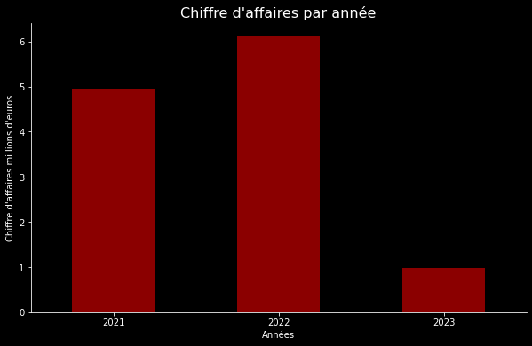

```python
# Visualiser le chiffre d'affaires par année
plt.figure(figsize=(10, 6))
ax = df_resampled['Revenue'].plot(kind='bar', color='darkred')
plt.title('Chiffre d\'affaires par année', fontsize=16)
plt.xlabel('Années')
plt.ylabel('Chiffre d\'affaires millions d\'euros')
ax.spines[['top', 'right']].set_visible(False)
ax.set_xticklabels(df_resampled['Year'])
plt.xticks(rotation=0)
formatter = ticker.FuncFormatter(lambda x, pos: '{:,.0f}'.format(x/1e6))
plt.gca().yaxis.set_major_formatter(formatter)
plt.grid(False)
plt.show()
```

L'année 2021 est incomplète, il manque les mois de janvier et février, tout comme l'année 2023 dont les données se résument à ces deux mêmes mois (janvier et février). En faisant la somme du CA 2021 et 2023 pour avoir une année complète on a 5918981 € de CA versus 6108681 € en 2022. On en déduit que **le chiffre d'affaires annuel moyen tourne autour des 6 millions d'euros**

```python
# Calcul du CA journalier, hebdomadaire et mensuel moyen
daily_revenue = revenue / 730
weekly_revenue = revenue / 104.28
monthly_revenue = revenue / 24
print('CA journalier moyen: ', int(daily_revenue),'€')
print('CA hebdomadaire moyen: ', int(weekly_revenue),'€')
print('CA mensuel moyen: ', int(monthly_revenue),'€')
```

```
CA journalier moyen:  16476 €
CA hebdomadaire moyen:  115340 €
CA mensuel moyen:  501152 €
```

### Etape 2.2 - Evolution du chiffre d'affaires dans le temps

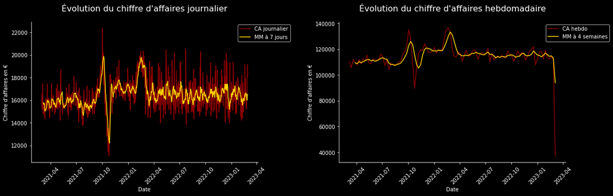

```python
# Afficher l'évolution du chiffre d'affaires journalier depuis le 1er mars 2021
daily_sales = df.loc['2021-03-01':'2023-02-28', 'price'].resample('D').sum()
rolling_daily_mean = daily_sales.rolling(window=7).mean()

weekly_sales = df.loc['2021-03-01':'2023-02-28', 'price'].resample('W').sum()
rolling_weekly_mean = weekly_sales.rolling(window=4).mean()

plt.figure(figsize=(24, 20))
plt.subplot(4,3,1)
sns.lineplot(data=daily_sales, label='CA journalier', color='darkred')
sns.lineplot(data=rolling_daily_mean, label='MM à 7 jours', color='gold')
plt.title('Évolution du chiffre d\'affaires journalier', fontsize=16, pad=20)
plt.xlabel('Date')
plt.ylabel('Chiffre d\'affaires en €')
plt.xticks(rotation=45)
plt.legend(bbox_to_anchor=(0.90, 1), loc='upper left')
sns.despine()

plt.subplot(4,3,2)
sns.lineplot(data=weekly_sales, label='CA hebdo', color='darkred')
sns.lineplot(data=rolling_weekly_mean, label='MM à 4 semaines', color='gold')
plt.title('Évolution du chiffre d\'affaires hebdomadaire', fontsize=16, pad=20)
plt.xlabel('Date')
plt.ylabel('Chiffre d\'affaires en €')
plt.xticks(rotation=45)
plt.legend(bbox_to_anchor=(0.90, 1), loc='upper left')
sns.despine()
plt.tight_layout(pad=3)
plt.show()
```

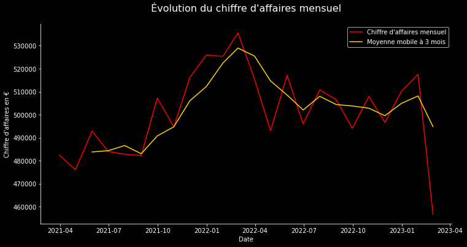

```python
# Afficher l'évolution du chiffre d'affaires mensuel depuis le 1er mars 2021
# On remarque une baisse d'ampleur inhabituelle en février 2023 mais,, avec 24 mois de données, nous n'avons pas assez de recul pour en tirer des conclusions

monthly_sales = df.loc['2021-03-01':'2023-02-28', 'price'].resample('M').sum()
rolling_monthly_mean = monthly_sales.rolling(window=3).mean()

plt.figure(figsize=(12, 6))
sns.lineplot(data=monthly_sales, label='Chiffre d\'affaires mensuel', color='red')
sns.lineplot(data=rolling_monthly_mean, label='Moyenne mobile à 3 mois', color='gold')
plt.title('Évolution du chiffre d\'affaires mensuel', fontsize=16, pad=20)
plt.xlabel('Date')
plt.ylabel('Chiffre d\'affaires en €')
plt.legend()
sns.despine()
plt.show()
```

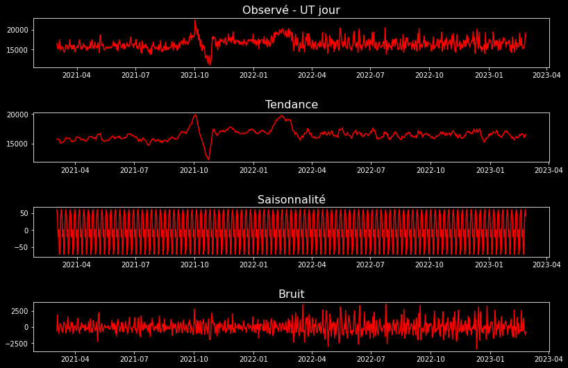

```python
# Décomposition saisonnière de la variation du chiffre d'affaires (journalier) pour visualiser la part de la variation liée à la tendance de fond
# celle liée à la saisonnalité et enfin celle causée par le bruit
result_daily = seasonal_decompose(daily_sales, model='additive')

fig, axs = plt.subplots(4, figsize=(12, 8))

axs[0].plot(result_daily.observed, color='red')
axs[0].set_title('Observé - UT jour', fontsize=16)

axs[1].plot(result_daily.trend, color='red')
axs[1].set_title('Tendance', fontsize=16)

axs[2].plot(result_daily.seasonal, color='red')
axs[2].set_title('Saisonnalité', fontsize=16)

axs[3].plot(result_daily.resid, color='red')
axs[3].set_title('Bruit', fontsize=16)

plt.tight_layout(pad=3.0)
plt.show()
```

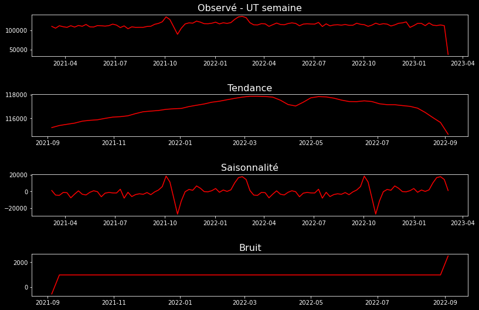

```python
# Décomposition saisonnière en UT semaine
result_weekly = seasonal_decompose(weekly_sales, model='additive')

fig, axs = plt.subplots(4, figsize=(12, 8))
axs[0].plot(result_weekly.observed, color='red')
axs[0].set_title('Observé - UT semaine', fontsize=16)

axs[1].plot(result_weekly.trend, color='red')
axs[1].set_title('Tendance', fontsize=16)

axs[2].plot(result_weekly.seasonal, color='red')
axs[2].set_title('Saisonnalité', fontsize=16)

axs[3].plot(result_weekly.resid, color='red')
axs[3].set_title('Bruit', fontsize=16)
plt.tight_layout(pad=3.0)
plt.show()
```

En UT jour on remarque, dans la composante tendance, un pic haussier en septembre 2021 suivi par une forte chute du CA le mois suivant. Hypothèse: **cette baisse soudaine du chiffre d'affaires coincide avec l'adoption par l’Assemblée nationale, le 6 octobre 2021, de la loi visant à améliorer l'économie du livre et à renforcer l'équité entre ses acteurs, loi qui a notamment contraint les librairies à imposer à leurs clients un prix minimum de frais de port pour les livres achetés en ligne**, quel que soit le commerçant, de la petite librairie à la grande plateforme de e-commerce. Cela vise à rétablir une concurrence plus équilibrée entre les libraires indépendants et les grandes plateformes en ligne.

Cependant, si on décompose en UT semaine, ce "mouvement" n'est plus visible dans la partie tendance. Par contre, on retrouve ce même phénomène dans la composante saisonnière et il se répète l'année suivante. **Les pics haussiers et baissiers de septembre 2021 et 2022 sont donc périodiques et certainement liés à la rentrée littéraire qui a lieu chaque année en septembre. Pendant cette période, de très nombreuses nouveautés sont publiées et de nombreux clients achètent ces livres puis le mois suivant on a le retour de baton; ces mêmes clients n'achètent plus, ils digèrent leurs achats**.

```python
# Il y a également un brusque décrochage en février 2023
# Comparons le CA de février 2022 à celui de février 2023
february_2022 = df.loc['2022-02-01':'2022-02-28', 'price'].sum()
february_2023 = df.loc['2023-02-01':'2023-02-28', 'price'].sum()
print('CA février 2022:', int(february_2022),'€')
print('CA février 2023:', int(february_2023),'€')
```

```
CA février 2022: 535571 €
CA février 2023: 456679 €
```

```python
# Voyons quelles catégories ont le plus contribué à la baisse
df_february_2022 = df.loc['2022-02-01':'2022-02-28']
categ_sales_february_2022 = {}
for categ in df_february_2022['categ'].unique():
   categ_sales_february_2022[categ] = int(df_february_2022.loc[df_february_2022['categ']==categ, 'price'].sum())

df_february_2023 = df.loc['2023-02-01':'2023-02-28']
categ_sales_february_2023 = {}
for categ in df_february_2023['categ'].unique():
   categ_sales_february_2023[categ] = int(df_february_2023.loc[df_february_2023['categ']==categ, 'price'].sum())

print('Ventes par catégorie février 2022:',categ_sales_february_2022)
print('Ventes par catégorie février 2023:',categ_sales_february_2023)
```

```
Ventes par catégorie février 2022: {'1': 213120, '0': 183197, '2': 139253}
Ventes par catégorie février 2023: {'0': 162457, '1': 180347, '2': 113875}
```